# Effective Data Visualisation with R **The {ggplot2} Package**

# Exercise

- Identify the **geoms**, **aesthetic mappings**, and **scales** employed in this data visualisation.

  Write {ggplot2} code to produce the data visualisation (ignoring labels).

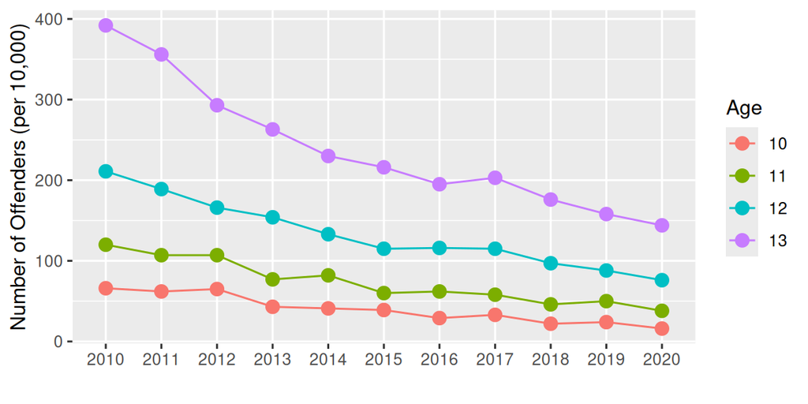

# Exercise

- Identify the **geoms**, **aesthetic mappings**, and **scales** employed in this data visualisation.

  Write {ggplot2} code to produce the data visualisation (ignoring labels).

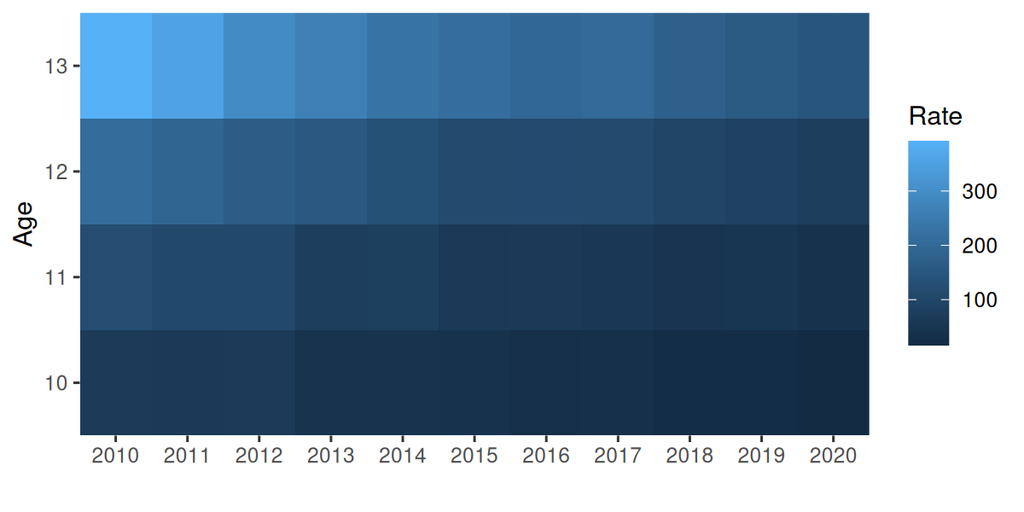

# Exercise

- The next data visualisation uses the `RWCperGame` data frame.

  ```r
  head(RWCperGame)
  ```

  ```
       country hemisphere yellowcards redcards cleanbreaks tackles points
  11   Namibia      South        1.00     0.50        2.50  102.00   9.25
  14   Romania      North        1.25     0.00        2.75  142.50   8.00
  3      Chile      South        1.25     0.00        3.75  132.25   6.75
  15     Samoa      South        1.25     0.25        3.75  109.50  23.00
  2  Australia      South        0.50     0.00        5.25  108.25  22.50
  7    Georgia      North        0.50     0.00        5.25  149.75  16.00
     conversions offloads tries   runs
  11        0.50     2.25  0.75  92.00
  14        0.75     1.50  1.00  81.00
  3         0.50     5.25  1.00 102.25
  15        2.00     9.25  2.75 102.50
  2         1.75     7.75  2.75 110.75
  7         1.00     8.00  1.75 114.00
  ```

# Exercise

- What values are being mapped in the data visualisation below?

  What **stat** is being used?

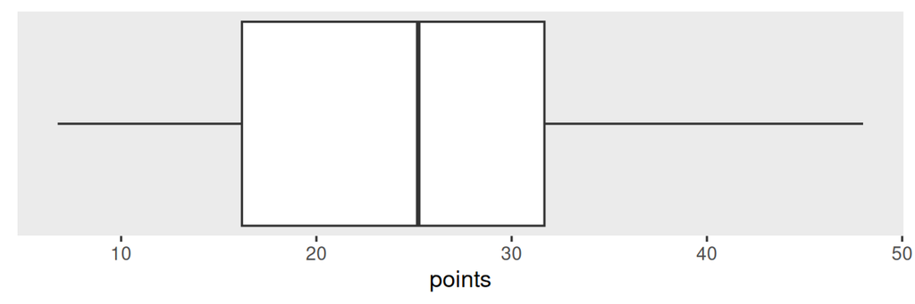